[OHI British Columbia](http://www.ohibc.org/) | [OHI Science](http://ohi-science.org) | [Citation policy](https://github.com/OHI-Science/ohiprep/releases)

# OHIBC: Resilience - Community Well Being Index prep

Compiled on Sun Oct 7 11:38:53 2018 by ohara

# 1 Summary

$$resilience_{rgn} = \frac{\sum_{i=1}^N (CWB_{csd} * pop_{csd})}{\sum_{i=1}^N pop_{csd}}$$

where $CWB_{csd}$ is the CWB score (component or total) for each of $N$ census subdivisions within the OHIBC region, and pop_{csd} is the portion of the population of that CSD within the OHIBC region.

# 2 Data

This layer relies on Community Well-Being Index data from Indigenous and Northern Affairs Canada (AADNC)

CWB Index:

- **Reference**:
- **Downloaded**: Aug 15, 2017 from:
  - https://www.aadnc-aandc.gc.ca/eng/1100100016579/1100100016580
- **Description**:
  - CWB Index Database for 1981, 1991, 1996, 2001, 2006, 2011
  - Also data dictionaries for each
- **Native data resolution**: Census Subdivision
- **Format**: .csv

# 3 Methods

## 3.1 Determine CWB Index values for BC subdivisions

metadata for Community Well-Being Index data

| field_name | description | definition |
| --- | --- | --- |
| CSD Code | Census Subdivision Code | Unique 7-digit code identifying each Census subdivision (CSD) in the file. |
| CSD Name | Census Subdivision Name | Name of the CSD in the file. |
| Census Population | Census Population | Population of the CSD based on the Census of Canada that was used to collect basic information from 100% of Canadian households. |
| GNR | Global non-response rate | The global non-response rate is an indicator of data quality used in estimates from the National Household Survey (NHS). A smaller GNR indicates lower risk of non-response bias and is preferable. The … |
| Income | Income score | Score of the CSD on the Income component. Component scores are included only if the community has a population of at least 250 individuals and the total number of individuals in the CSD with income ha… |
| Education | Education score | Score of the CSD on the Education component. Component scores are included only if the community has a population of at least 250 individuals and the sum of the numerators used to calculate the Educat… |
| Housing | Housing score | Score of the CSD on the Housing component. Component scores are included only if the community has a population of at least 250 individuals and the sum of the numerators used to calculate the Housing … |
| Labour Force Activity | Labour Force Activity score | Score of the CSD on the Labour Force Activity component. Component scores are included only if the community has a population of at least 250 individuals and the sum of the numerators used to calculat… |
| CWB | CWB score | Score of the CSD on the Community Well Being index (CWB). The CWB score is included if the CSD had at least a weighted population count of 65 and an unweighted count of 10. |
| Community Type | Type of collectivity | This variable indicates if the CSD is categorized as either a First Nation, an Inuit community, or a Non-Aboriginal community. |

Cut all-Canada CWB index down to just OHIBC census subdivisions. For this we use the OHIBC-to-census lookup from Clean Waters:Pathogens data prep. Note the CSD data only goes back to 2001; the CWB data only goes up to 2011.

## 3.2 Calculate layers

For each region for each year, calculate a population-weighted value for each of the components and the overall index. We will do this for both overall population and First Nations population.

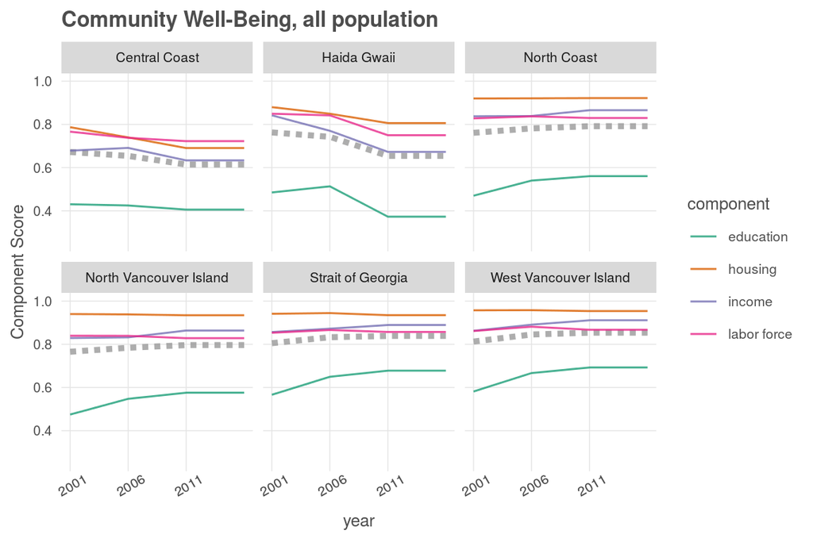

|  | rgn_id | cwb_comp | year | cwb_score | rgn_name | rgn_code |
| --- | --- | --- | --- | --- | --- | --- |
| 1 | 1 | cwb | 2001 | 0.7612 | North Coast | NC |
| 2 | 1 | cwb | 2002 | 0.7653 | North Coast | NC |
| 3 | 1 | cwb | 2003 | 0.7694 | North Coast | NC |
| 4 | 1 | cwb | 2004 | 0.7735 | North Coast | NC |
| 5 | 1 | cwb | 2005 | 0.7776 | North Coast | NC |
| 6 | 1 | cwb | 2006 | 0.7817 | North Coast | NC |
| 7 | 1 | cwb | 2007 | 0.7837 | North Coast | NC |
| 8 | 1 | cwb | 2008 | 0.7857 | North Coast | NC |
| 9 | 1 | cwb | 2009 | 0.7878 | North Coast | NC |
| 10 | 1 | cwb | 2010 | 0.7898 | North Coast | NC |

[output cut: 470 more lines]

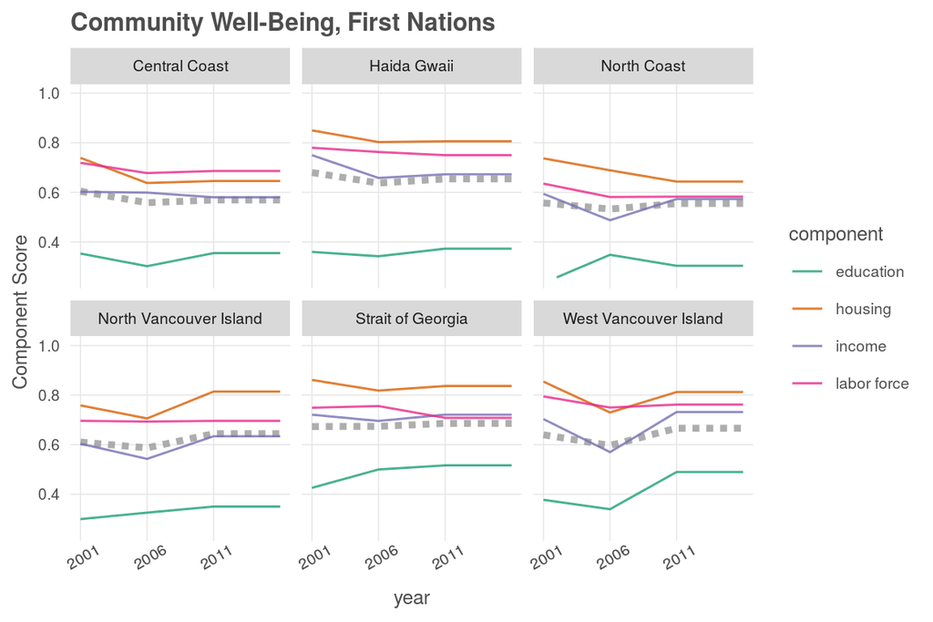

|  | rgn_id | cwb_comp | year | cwb_score | rgn_name | rgn_code |
| --- | --- | --- | --- | --- | --- | --- |
| 1 | 1 | cwb | 2001 | 0.5575 | North Coast | NC |
| 2 | 1 | cwb | 2002 | 0.5526 | North Coast | NC |
| 3 | 1 | cwb | 2003 | 0.5476 | North Coast | NC |
| 4 | 1 | cwb | 2004 | 0.5427 | North Coast | NC |
| 5 | 1 | cwb | 2005 | 0.5377 | North Coast | NC |
| 6 | 1 | cwb | 2006 | 0.5328 | North Coast | NC |
| 7 | 1 | cwb | 2007 | 0.5372 | North Coast | NC |
| 8 | 1 | cwb | 2008 | 0.5417 | North Coast | NC |
| 9 | 1 | cwb | 2009 | 0.5461 | North Coast | NC |
| 10 | 1 | cwb | 2010 | 0.5506 | North Coast | NC |

[output cut: 470 more lines]

# 4 Provenance

- *Run ID: 1 (82d3ab7); run tag: “standard run”*
- *Run elapsed time: 41.587 seconds; run memory usage: 2030 MB*
- *System info:*
  - *System: Linux, Release: 4.4.0-133-generic. Machine: x86_64. User: ohara.*
  - *R version: R version 3.4.4 (2018-03-15), Platform: x86_64-pc-linux-gnu, Running under: Ubuntu 14.04.5 LTS.*
  - *Attached base packages: stats, graphics, grDevices, utils, datasets, methods, base*
  - *Other attached packages: bindrcpp_0.2.2, provRmd_0.1.1, RColorBrewer_1.1-2, forcats_0.3.0, stringr_1.3.1, dplyr_0.7.6, purrr_0.2.5, readr_1.1.1, tidyr_0.8.1, tibble_1.4.2, ggplot2_3.0.0, tidyverse_1.2.1, sf_0.6-3*

[figure not shown]

[output not shown]

[output cut: 26 more lines]